# Creating Clade A v Clade C Balanced DF

Cassandra Sperow

2023-11-15

## Note to the Reader: This file is for the Data 642 Adv ML class, not for the practicum of Data 793.

- In Data 793, the classification modeling was for CLade C with Ridge, Lasso, and tree methods. Please refer to the ‘analysis’ main list of files for Data 793 work related to **Clade C (278 rows of Clade C v non-Clade C).** The balanced 278-row dataset for this was created in ‘Experimental Logistic Regression Clade C.Rmd’ and the **final modeling** is revised and confirmed in ‘Ridge_Lasso_Modeling_Revised.Rmd’ and ‘Tree_Methods_Clade_C.Rmd’.

### The folder ‘data_642_jupyter_notwbooks’ is work related to *only* that course, Fall 2023.

- This extra work in Data 642 is included in this directory because of the batch density plots in Python created for viewing the densities of Clades A and C as they were used in the final presentation for Data 793, but only for visualization purposes of the two primary clades in the coral data.
- The Data 642 work will be different in nature and not related to client requests; however, permission was granted by the client to use the coral data for the projects associated with both courses (Data 793 and Data 642).

## Read in Data

```r
read_csv("../output/rev_coral_join.csv") -> rev_coral_join
```

## Subset Clade C as it’s the minority

- Clade A is the majority
- Clade D, G and B only have 1 or 2 rows; therefore, need to focus on Clade A or Clade C.

```r
# Extract the minority class samples (139 observations)
minority_class_C <- rev_coral_join[rev_coral_join$Clade == 'C', ] # 139

# Extract the majority class samples (the rest of the dataset)
majority_class_A <- rev_coral_join[rev_coral_join$Clade == 'A', ] # 628

######### Percent Clade C v Clade A
139/(139 + 628)
```

```
## [1] 0.1812256
```

- 18 % is not bad for the minority class, so since it’s better to go with more data, we will keep Clade A with over 600 samples so that we can model it better. Clade C was already modeled (see ‘Ridge & Lasso Modeling.Rmd’) but Clade A will be modeled in python for Data 642 project.

```r
# Combine the datasets
AC_df <- rbind(majority_class_A, minority_class_C)

# Shuffle the rows to randomize the order
AC_df <- AC_df[sample(nrow(AC_df)), ]
```

```r
dim(AC_df) # 767 x 5897
```

```
## [1]  767 5897
```

```r
head(AC_df)
```

```
## # A tibble: 6 × 5,897
##   ITS2_type Clade Majority sample_id  its2_count species region reef  ASV0001
##       <dbl> <chr> <chr>    <chr>           <dbl> <chr>   <chr>  <chr>   <dbl>
## 1     84574 A     A1j      PFAR-R3-30      11611 P       FAR    R3          0
## 2     85599 A     A1       SWAJ-R3-13      11882 S       WAJ    R3      24609
## 3     84609 A     A1       SYAN-R1-3         609 S       YAN    R1          0
## 4     85591 A     A1       SFAR-R1-29      14311 S       FAR    R1          0
## 5     84781 C     C1       SWAJ-R3-13        107 S       WAJ    R3      24609
## 6     84572 A     A1/A1j   PKAU-R2-21      11316 P       KAU    R2          0
## # ℹ 5,888 more variables: ASV0002 <dbl>, ASV0003 <dbl>, ASV0004 <dbl>,
## #   ASV0005 <dbl>, ASV0006 <dbl>, ASV0007 <dbl>, ASV0008 <dbl>, ASV0009 <dbl>,
## #   ASV0010 <dbl>, ASV0011 <dbl>, ASV0012 <dbl>, ASV0013 <dbl>, ASV0014 <dbl>,
## #   ASV0015 <dbl>, ASV0016 <dbl>, ASV0017 <dbl>, ASV0018 <dbl>, ASV0019 <dbl>,
## #   ASV0020 <dbl>, ASV0022 <dbl>, ASV0023 <dbl>, ASV0024 <dbl>, ASV0025 <dbl>,
## #   ASV0027 <dbl>, ASV0030 <dbl>, ASV0031 <dbl>, ASV0032 <dbl>, ASV0033 <dbl>,
## #   ASV0034 <dbl>, ASV0035 <dbl>, ASV0036 <dbl>, ASV0037 <dbl>, …
```

## Write to File

```r
write_csv(AC_df, "../output/AC_df.csv")
```

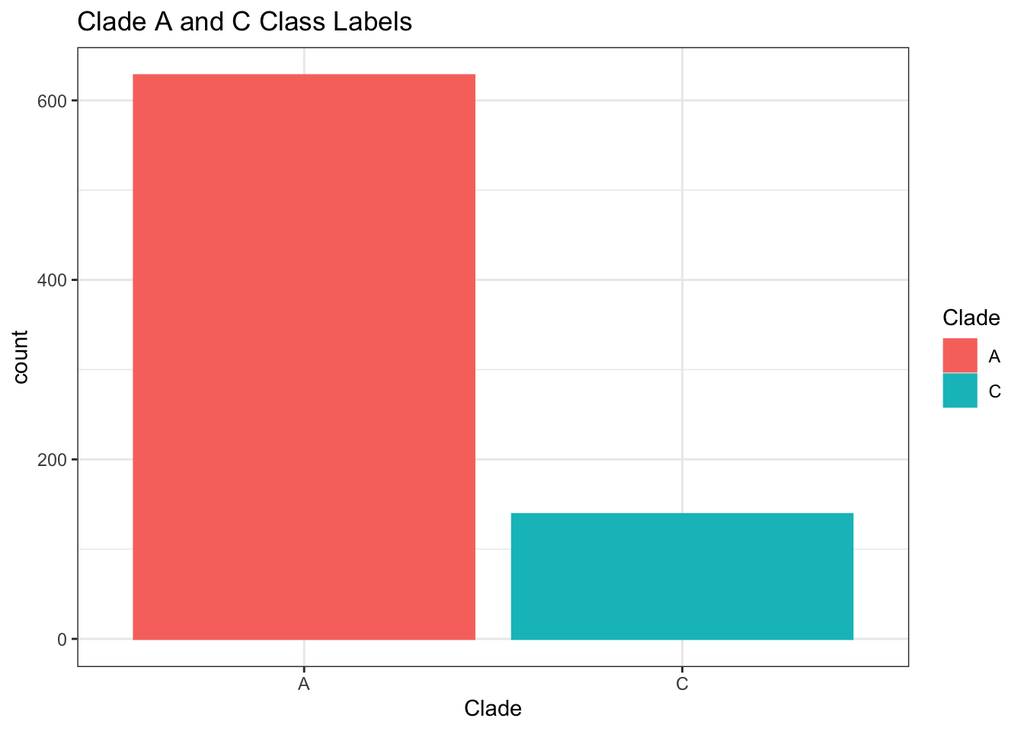

```r
AC_df %>%
  ggplot(aes( x = Clade, color = Clade, fill = Clade)) +
  geom_histogram(stat = "count") +
  theme_bw() +
  ggtitle("Clade A and C Class Labels")
```

# Make files with CLR transofmraiton for first 500, 1000, 2000

```r
# clr on first 500 ASVs
bind_cols(
  AC_df[,1:8],
  AC_df[,9:508] %>%
    compositions::clr()
) -> AC_clr_df_500

# clr on first 1000
bind_cols(
  AC_df[,1:8],
  AC_df[,9:1008] %>%
    compositions::clr()
) -> AC_clr_df_1000

# clr on first 2000
bind_cols(
  AC_df[,1:8],
  AC_df[,9:2008] %>%
    compositions::clr()
) -> AC_clr_df_2000
```

## Write to File

```r
write_csv(AC_clr_df_500, "../output/AC_clr_df_500.csv")
write_csv(AC_clr_df_1000, "../output/AC_clr_df_1000.csv")
write_csv(AC_clr_df_2000, "../output/AC_clr_df_2000.csv")
```

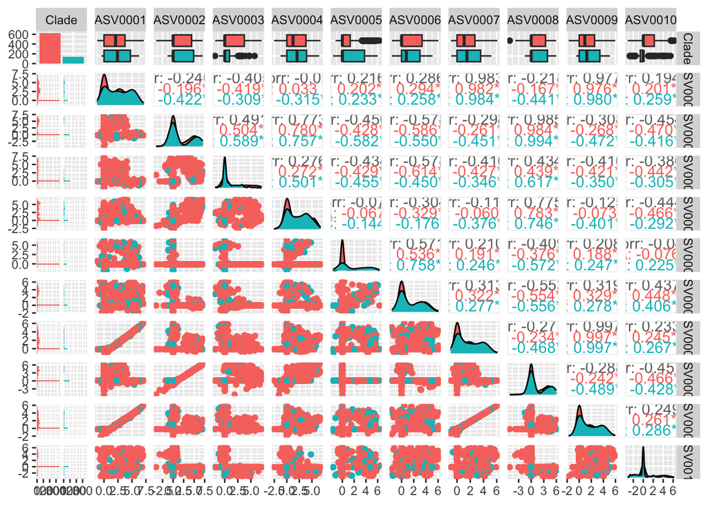

```r
GGally::ggpairs(AC_clr_df_1000[, c(2, 9:18)], aes(color = Clade)) -> ggpairs_AC
ggsave("../plots/ggpairs_AC.png",
       width = 11, height = 12)

ggpairs_AC
```

```r
# Create density plots for each numeric column
density_plots <- map(names(AC_clr_df_1000)[9:20],
                     function(var) {
                        ggplot(AC_clr_df_1000, aes(x = AC_clr_df_1000[[var]], fill = Clade)) +
    geom_density(alpha = 0.5) +
    ggtitle(paste( var)) +
    theme_minimal() +
                         xlab(NULL)
                        # theme(axis.text.x = element_blank(), axis.ticks.x = element_blank())
})
```

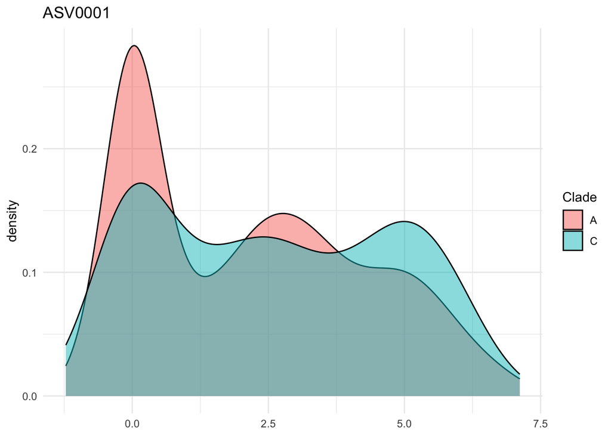

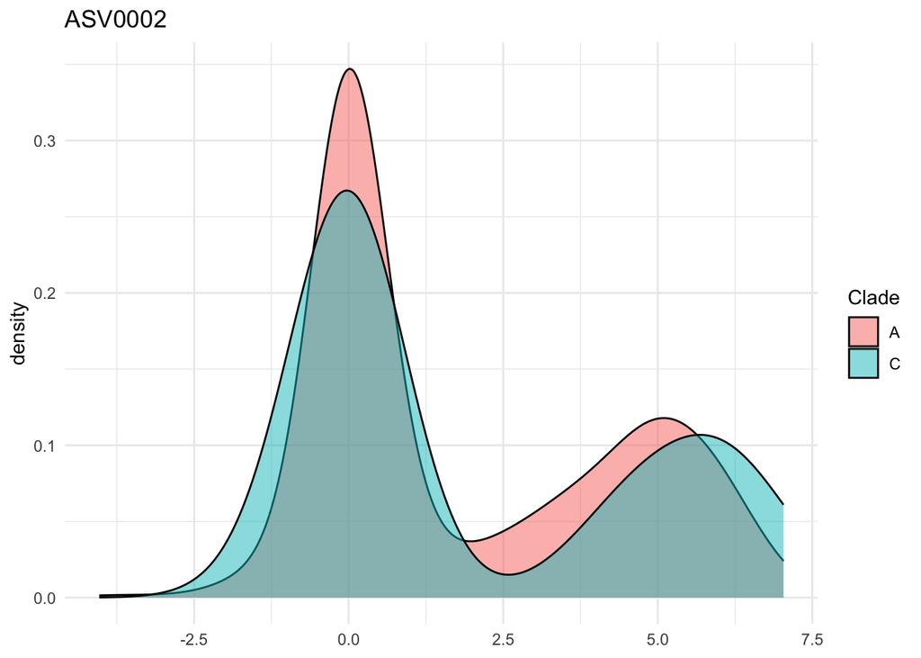

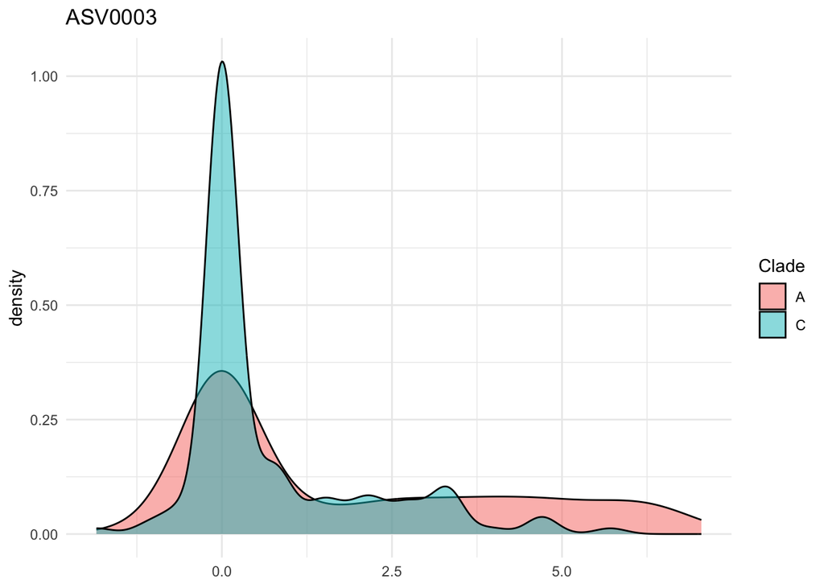

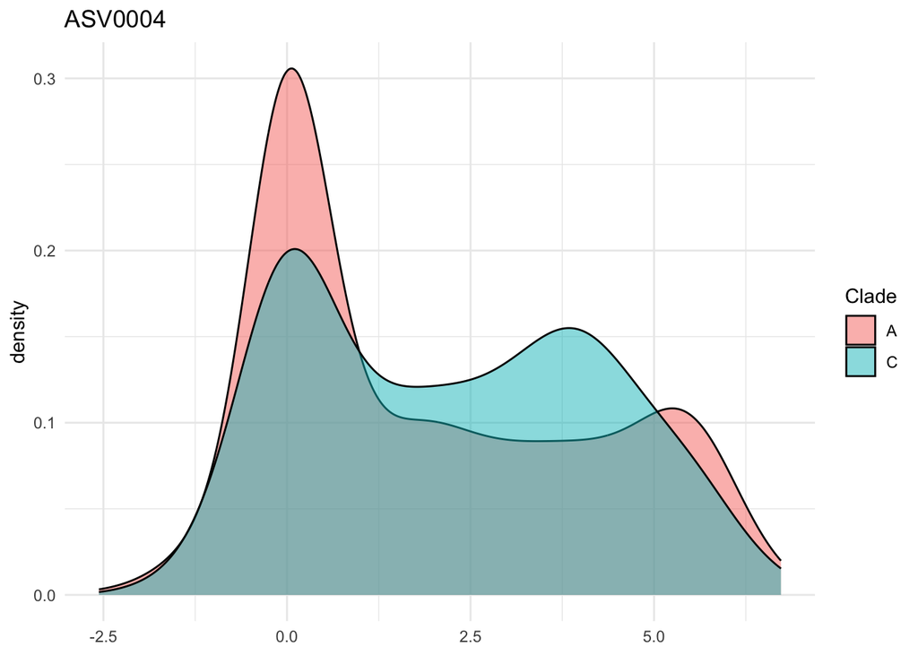

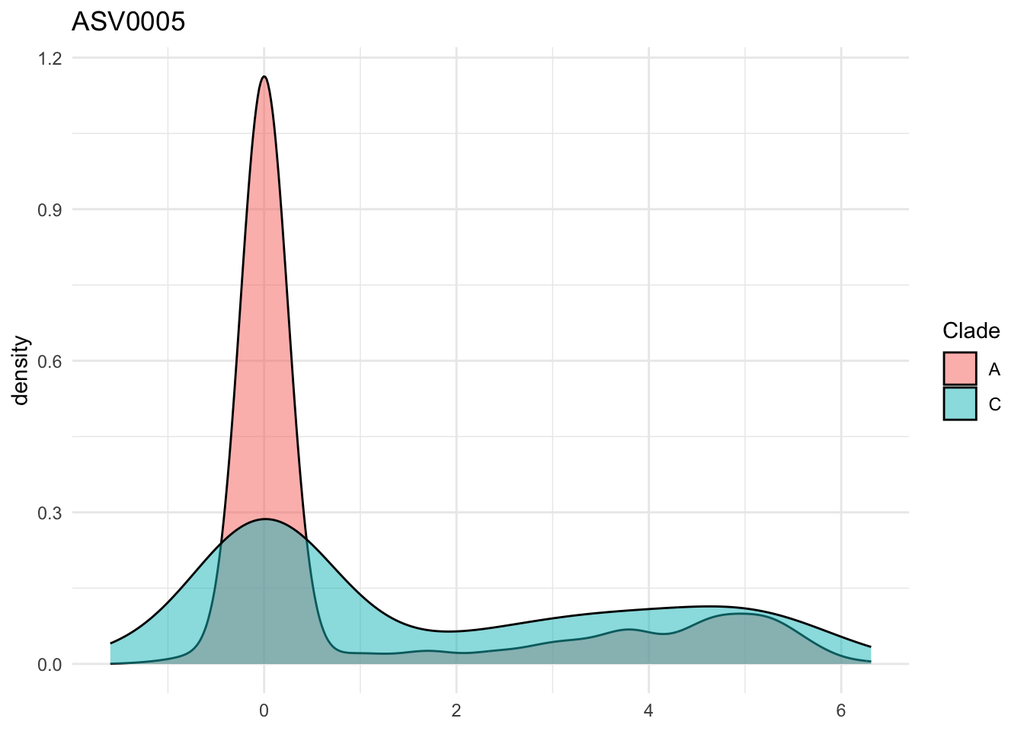

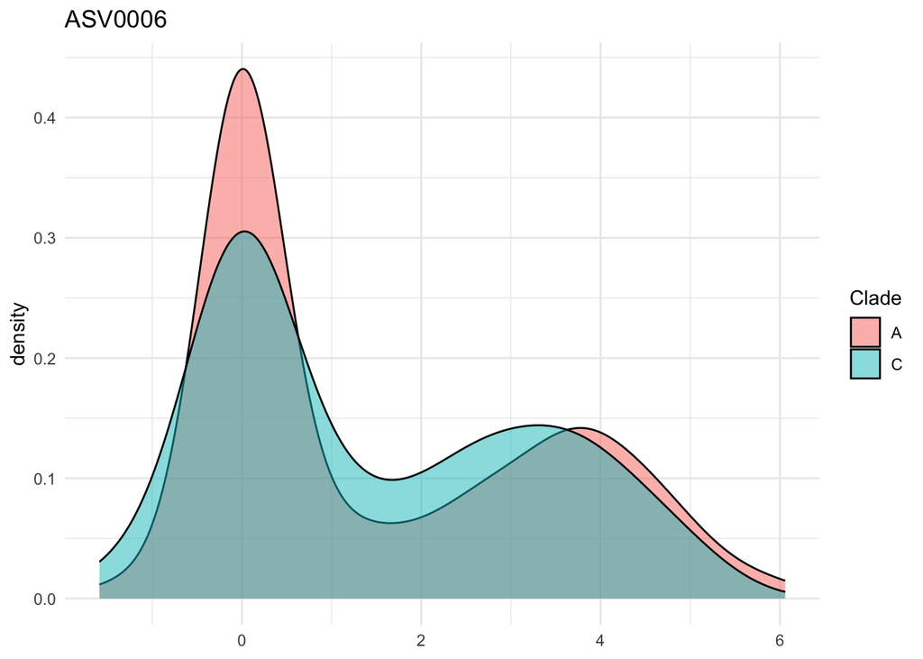

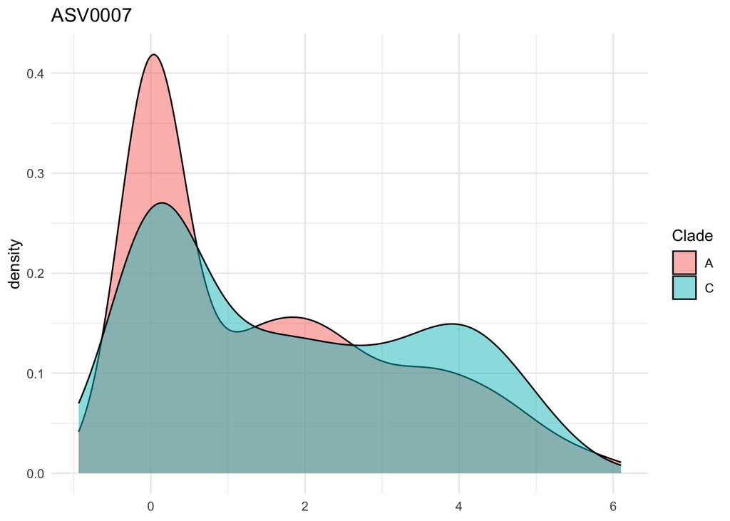

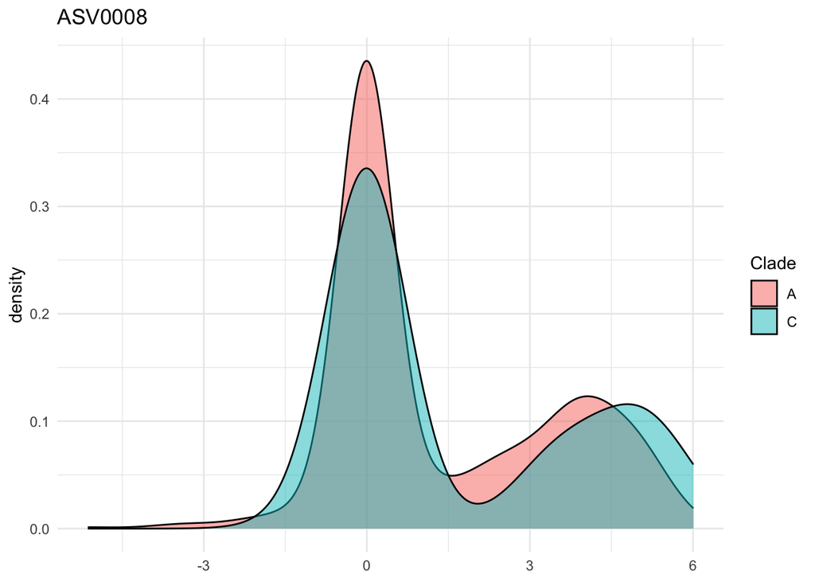

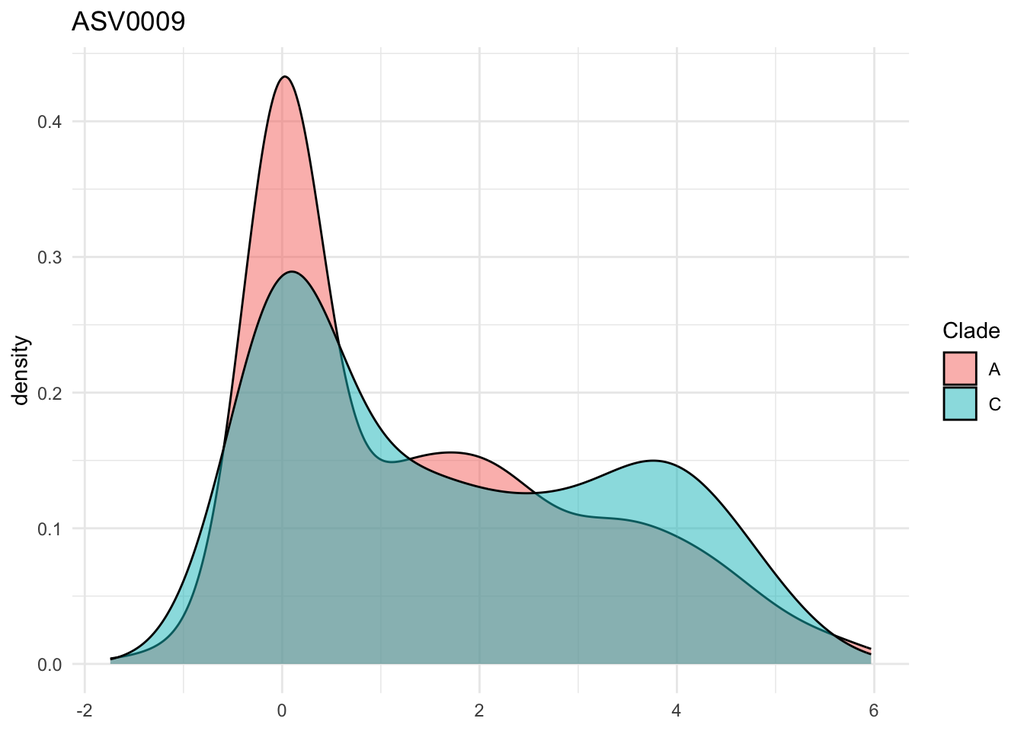

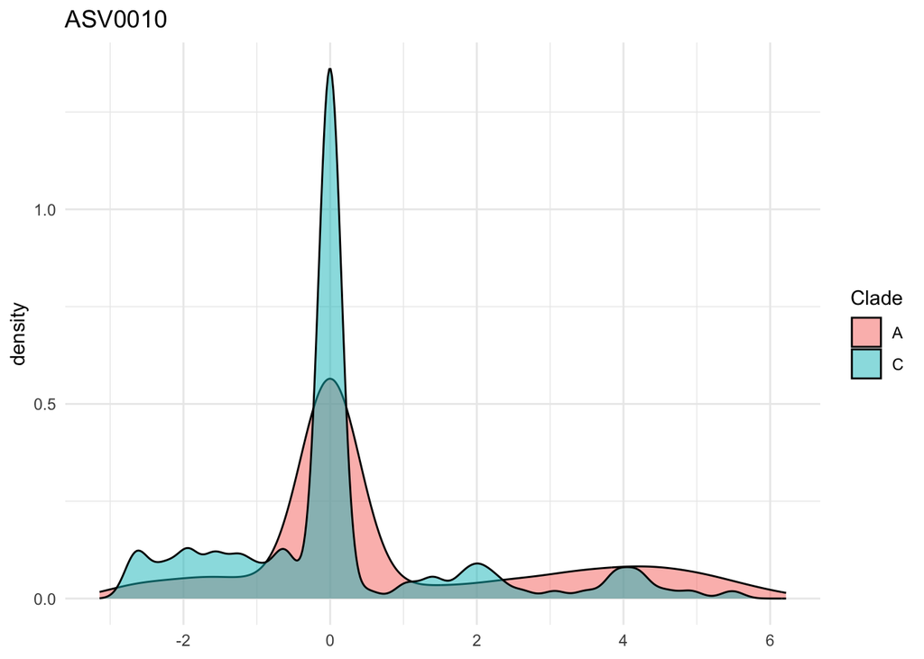

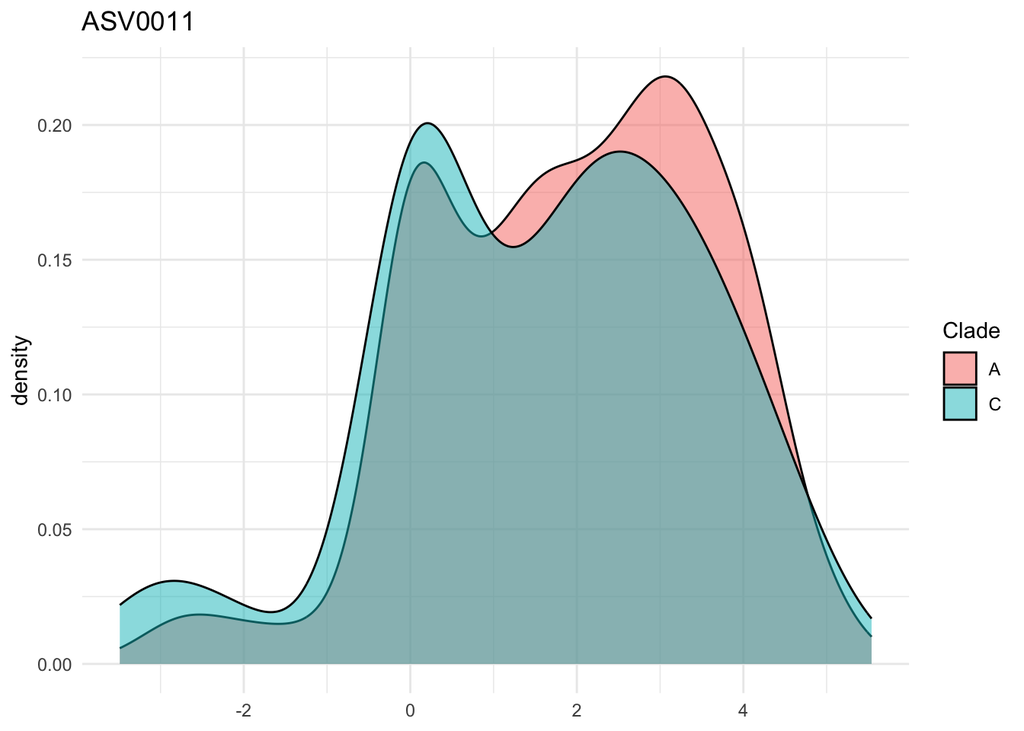

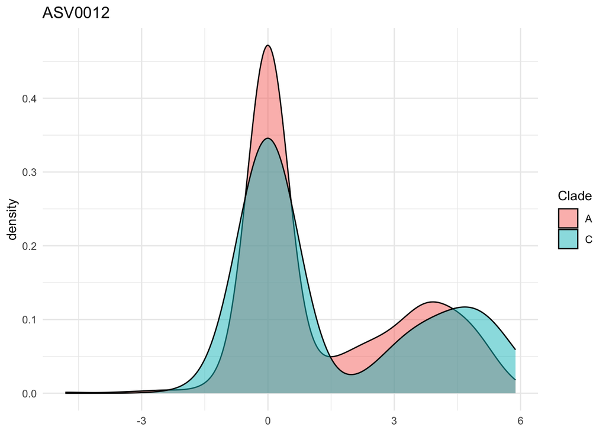

```r
density_plots
```

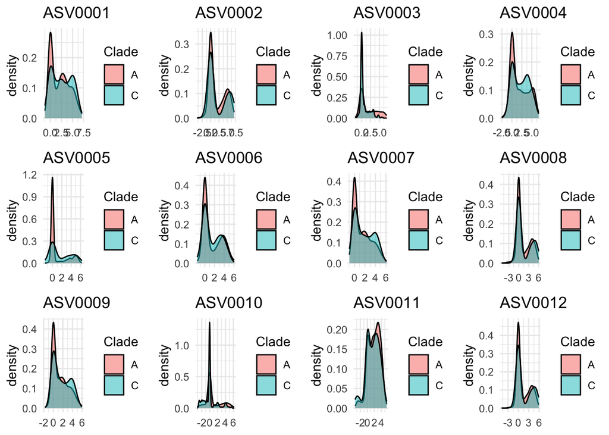

```r
# Arrange the plots on a grid
library(cowplot)
plot_grid(plotlist = density_plots, ncol = 4)  # Change 'ncol' as needed
```